# Movie Reviews

Austin Halvorsen, Foster Nuffer, Guilherme (Gui) Cidade

March 16, 2019

## Our Project

Did you know that Roger Ebert (movie critic) didn’t like Footloose? He called it “seriously confused”. That didn’t matter to the audiences They saw it and loved it and many still do. Do initial reviews of a movie tell how it will be viewed over time? Do the reviews of a movie change over time? These are questions we will try to get answers to.

Explore the tabs below from week to week to see what work was done to arrive at our final analysis.

### Project Details (Week 7)

#### Introduction

1. *Determine if movie reviews, positiveness and negativeness, change over time:* Using historical movie reviews data, determine if initial reviews of a movie will be telling of future success or failure.
2. *Collaborate effectively as a group for a common goal:* Using collaboration tools of Facebook Messenger, Google Drive and email for communication, we are striving for effective communication to achieve our groups proposed goal.

#### The Problem

The opportunity that we are investigating is that we could be able to tell sooner if a motion picture will be a hit sooner based of the feedback received. This information could help identify features of a movie that make it more likely to become a classic or help increase revenue over time.

#### Potential Dataset

We will be pulling information from IMDB and rottentomatoes via web scraping. These are the links to the websites: IMDB and rottentomatoes.

#### Design Document

This design document outlines the deliverables and what week they will be completed in. See a summary of the weeks listed below.

##### Week 7

1. The deliverable for this week is this document. Provide an outline of all aspects of the project with a goal of the final deliverable. Describe the processes that will be used, possible tools and outcomes.

##### Week 8

**A Usable dataset**

- **Gathering**:
  - We selected a total of six (6) movies via random sample. We will select from two different years, they must be longer than 60 minues and have a popularity of greater than 1000 (IMdB)
  - The movies we sampled were: **American Pysco, Anacondas, Dodgeball, The Polar Express, The Adventures of Rocky and Bullwinkle**, and **Wonderboys**
- **Tools**:
  - We will be using webscraper and R for our analysis
- **Scrape Data**:
  - Using webscraper, we pulled all the text reviews and dates of reviews for each of our movies.
- **Cleaning**:
  - Normalizing dates: **Austin**
  - Split Date into columns: **Austin**
  - Add Grouping by dates: **Foster**
  - Clean the text:
    1. Remove Punctuation: **Foster**
    2. Add word count: **Gui**
    3. Change to all lowercase: **Gui**
- **Profiling Data**:
  1. Check basic data integrity
  2. Find out whether existing data can be easily used for other purposes
  3. Improve the ability to search data by tagging it with keywords, descriptions, or assigning it to a category
  4. Assess data quality, including whether the data conforms to particular standards or pattern
  5. Assess the risk involved in integrating data in new applications, including the challenges of joins
  6. Discover metadata of the source database, including value patterns and distributions, key candidates, foreign-key candidates, and functional dependencies
  7. Assess whether known metadata accurately describes the actual values in the source database
- **Report Learnings**:
  - Individually report on what you learned from the previous week.

##### Week 9

**Pattern and Visualization**

1. Pro/Con list for patterning and visualization tools: **All**
2. Do pattern and visualizing on dataset
3. Record the learning excerpts about Patterning and Visualizing
4. Report Learnings and reply to others

##### Week 10

**Optimizing, Forecasting, Predicting Deliverables**

1. Research/learn about Optimizing, Forecasting, Predicting
2. Apply learnings to the data set.
   1. Team members need to contribute at least 1 optimization, forecasting, or predicting method/example
   2. Explain any insights you get from this method.
   3. Report pros and cons of the tools used for Optimizing, Forecasting or Predicting method/examples
   4. Record learnings experiences

#### Tools

For this project, we are using some new tools to do our analysis. We will be using R for our data analysis. We are using ‘webscraper’ to collect data from the internet and excel to compile and some reporting for our final analysis.

#### Risks

Some of the risks that we are likely to encounter with this project are that we are using new programs that we have had limited exposure to. This may inhibit the depth of our analysis that we are able to perform. Another risk is that getting full accurate data of the internet may prove challenging if we cannot access the correct sources. The other challenge is that we are working across time zones, so communication is critical and may prove hard to coordinate with varying schedules.

#### Document/Explanation

All of the ddocumentation is detailed within this document.

### Week 8

#### Project Update

We have posted all of our week 7 work and have continued scraping and collecting our data for the following weeks.

#### Deviations

We had to change some movie years since some reviews for movies did not exist in our original year, so we choose movies from years 2000 and 2004.

#### Tool Learning

**Gui**

Pulling the data from Rotten Tomatoes and imdb was difficult. I ran into issues with pagination on the web sites. I also ran into an issue with my CSV files. They didn’t import into Excel correctly.

Another frustration was switching from web scraper to grepsr. The second tool was simpler, but the output gave me the csv issue.

**Foster**

I spent a lot of time delving into web scraper. A lot more time that I expected. Out new tool grepsr worked, but I felt like switching back to web scraper since is was more powerful and free! In the end I learned how to deal with two kinds of pagination. A page forward button and a “Load More” button. I also had to learn how to group items to form an element so that the dates came with the correct review.

**Austin**

From our group, I believe that we learned that communication and setting specific time to meet is extremely helpful. Following up is also very helpful as well so that we make sure all our points get covered for the week.

Profiling our data: To make sure that our data was complete and accurate, we used data directly from the source to compile our dataset. Since we didn’t perform any transformations or complex joins, we feel assured that our data is usable for purposes of this analysis.

**All**

We had an issue with available data. Originally, we expected to get movie data from Rotten Tomatoes for a 1980 movie. The problem was that Rotten Tomatoes was not started until 1998. To solve this, we changed the movies we used to a year after Rotten Tomatoes was started.

From this week, we performed a lot a cleaning on our data. We formatted the dates in our dataset and split them up to get month day and year values for different grouping methods. We also cleaned up the text in order to do sentiment analysis on our data. We also compiled our text reviews so that we had it neat and orderly for our analysis.

#### Cleaning Methods

We used excel to clean the majority of our data. We also used functions in R to clean our data as well. See the “Data” tab to see a what our data looked like after being cleaned.

#### Document/Explanation

All documentation is contained within this docuement.

### Week 9

#### Project Update

We have completed the cleaning of our document and are moving on to creating some visualizations, finding patterns and/or outliers.

#### Deviations

We had to make some modifications to what type of reviews we were looking for in order to find more relevant reviews to what we were looking for. For example, we decided that, in addition to critic reviews, we also needed to pull user reviews to make sure that we were fully analyzing the sentiment of the movie and not just from one, potentially biased, side.

#### Tool Learning

Using new tools is a challenge, we discovered the following when using our analysis tool to run our reports.

- **R:**
  - *Pros:* It is really good at creating charts and running functions.
  - *Cons:* but not everyone on our team knew how to use it and it made explaining parts of the tool difficult.
- **Excel:**
  - *Pros:* It is easy to use for a majority of applications. It was covered in class extensively and used for many of the projects. Our team had a solid understanding of how it works and how to do our analysis in it.
  - *Cons:* Not as powerful as other software (i.e. Extra steps required, additional add-ons, etc). Has limits in the types of charts it can create.

#### Patterns - Outlier - Visualization

**Foster**

In this visual, we are looking for patterns in when the reviews were entered. Trying to understand if time of year influenced number of reviews

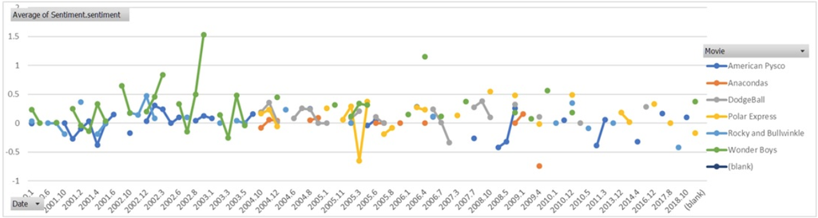

This visual, made in R, looks for the same pattern as above - when were reviews entered.

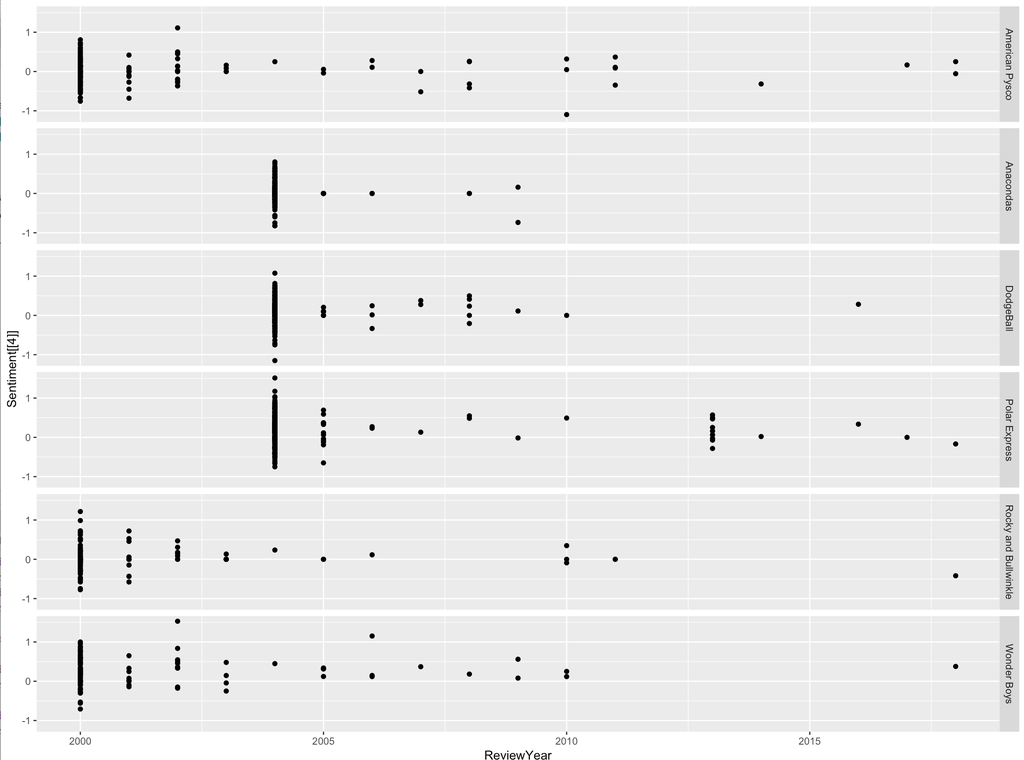

This chart helps see what reviews were negative and which were positive.

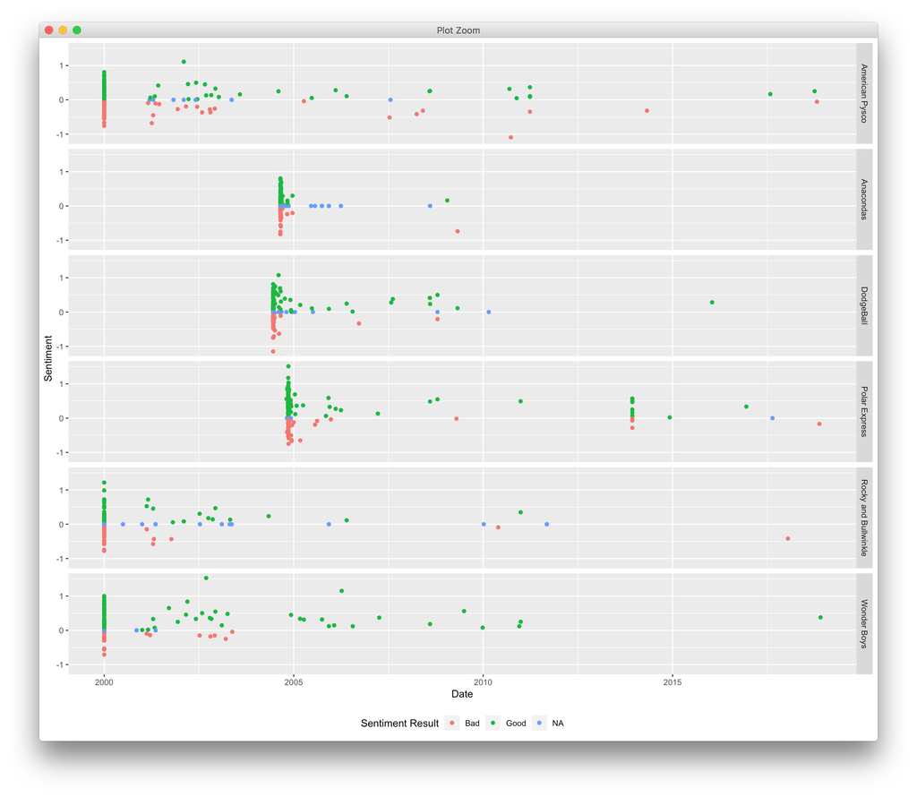

**Austin**

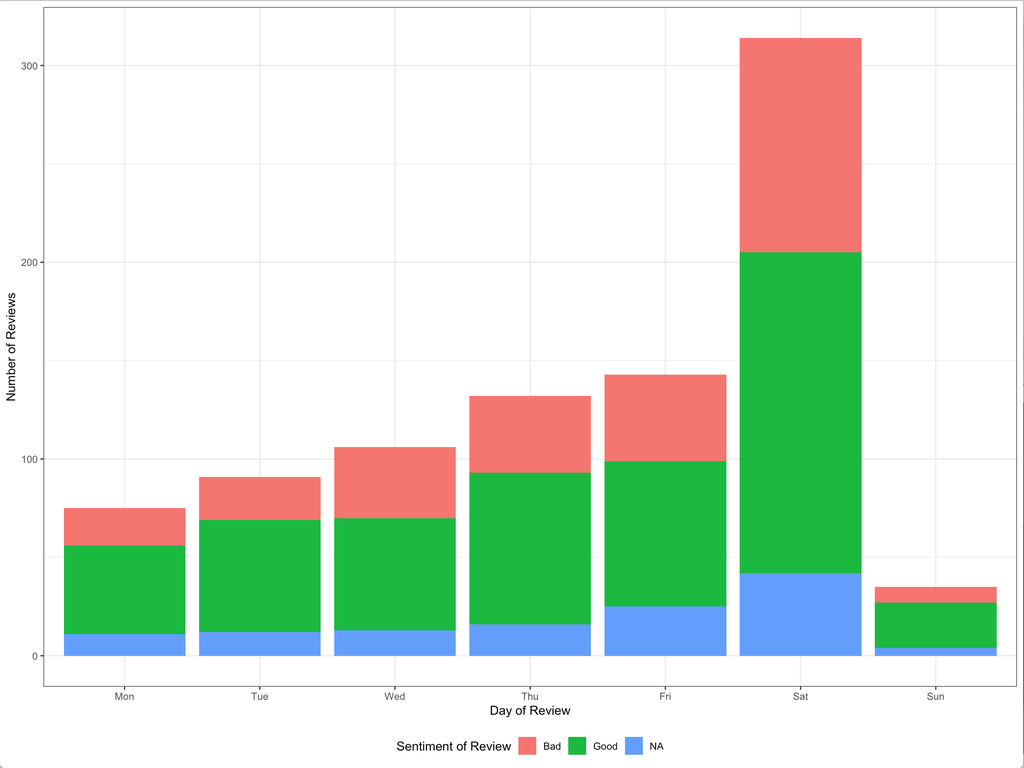

For the second visualization, I wanted to see the reviews stacked on top of each other. So This groups the movie by year and shows the total number of reviews by year and which ones were bad and which ones were good.

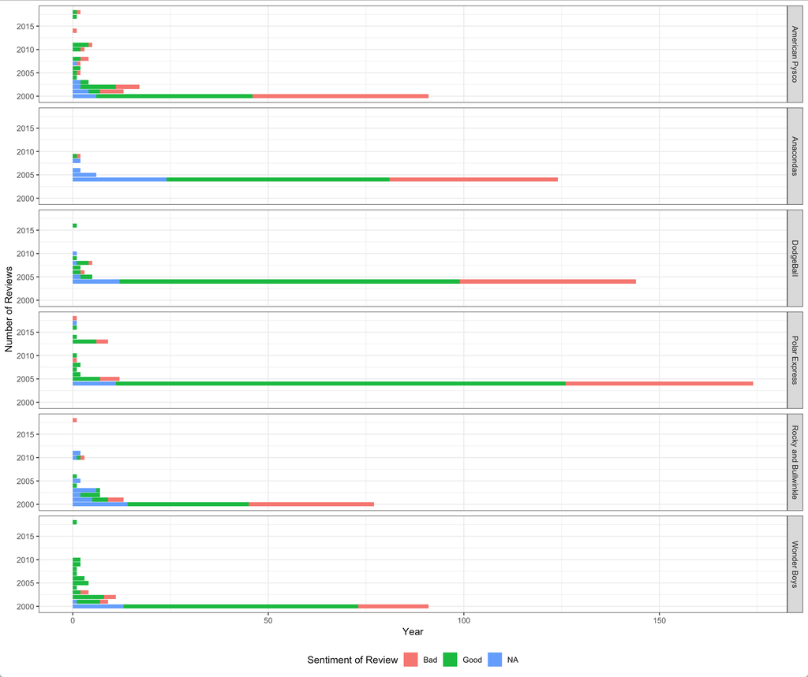

**Gui**

It is fun to look at the data. Visuals help identify areas to drill into. There are more questions after looking at the visuals than there were before. More digging to do!

#### Document/Explanation

- There was a lot of overlapping travelling which made it difficult to coordinate times with the members during this week.
- Learning new tools also proved to be fairly challenging as we began to learn them. It was helpful to have a team member who was familiar to use the tool. It made getting deliverables done more efficient.

### Week 10

#### Project Update

We are looking at optimizing our data sets and performing some forecasting to our analysis as well. See the attached spreadsheet for our forecasting example.

#### Deviations

None for this section.

#### Tool Learning

We used R more in depth this week. We wanted to recreate some of the cleaning, visualization, and reporting methods that we had used in excel, but in R, to see if we could change how we did our processes in order to make our project run smoother or faster. We found that R is a powerful tool, but can also be complicated. There is a learning curve to it, but it can do all of what excel can do and ususally a lot quicker.

#### Optimization - Forecasting - Predicting Method

For our optimization, we looked further into our datasets to see what improvements we could make to make our data tell more about the reviews we were seeing. We discovered a lot of interesing things in our dataset, particularly, seasonality. Take a look at a screenshot exerpt below from our forecast:

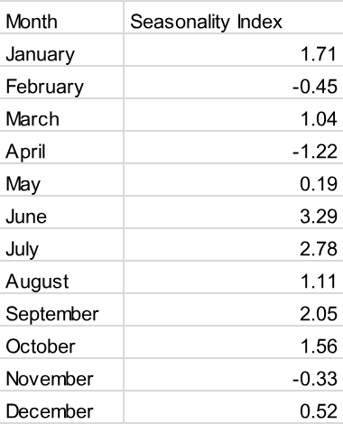

Something interesting here is that we see a consistant uptick in sentiment from reviews in June and a consistent dip in the end of the year. (See the attached excel sheet for a more detailed chart).

#### Document/Explanation

We found a lot of interesting aspects from our data. Of which, that it is hard to predict movie sucess based on the reviews of a movie. However, the initial reviews typically indicate if a movie is good or not in the long run. For example, if a movie recieves *generally positive* reviews during its initial release, then it will typically continue to receive *generally positive* reviews.

Just using our sentiment score to average out each sentiment, we get the following averages.

```r
average_sent <- movies %>% group_by(MovieTitle) %>% summarise(average = mean(Sentiment.sentiment))

average_sent %>%
  kableExtra::kable() %>%
  kableExtra::kable_styling(bootstrap_options = c("striped", "hover"))
```

| MovieTitle | average |
| --- | --- |
| American Pysco | -0.0018270 |
| Anacondas | 0.0480736 |
| DodgeBall | 0.1073100 |
| Polar Express | 0.2092605 |
| Rocky and Bullwinkle | 0.0385189 |
| Wonder Boys | 0.2444837 |

### Data

Here is the clean data we used to generate the graphs in this document.

```r
table_movies %>%
  kableExtra::kable() %>%
  kableExtra::kable_styling(bootstrap_options = c("striped", "hover"))
```

| MovieTitle | ReviewDate | ReviewDay | ReviewYear | ReviewMonth | ReviewTextFixed | Sentiment.sentiment | SentimentType |
| --- | --- | --- | --- | --- | --- | --- | --- |
| American Pysco | 2002-12-08 | Sun | 2002 | 12 | it s smart frightening and funny | 0.3265986 | Good |
| American Pysco | 2011-03-28 | Mon | 2011 | 3 | the slick satire cleverly equates materialism narcissism misogyny and classism with homicide but you may laugh so loud at the protagonist that you won t be able to hear yourself laughing with him | 0.3676520 | Good |
| American Pysco | 2000-01-01 | Sat | 2000 | 1 | a misfiring black comedy | 0.1250000 | Good |
| American Pysco | 2018-10-01 | Mon | 2018 | 10 | i ve always found mary harron s vision of bret easton ellis s arch satire of 80s greed excess and grooming to be a lot funnier than its reputation | 0.2506887 | Good |
| American Pysco | 2002-08-29 | Thu | 2002 | 8 | less a noble failure than a very minor miracle | 0.4500000 | Good |
| American Pysco | 2001-10-30 | Tue | 2001 | 10 | na | 0.0000000 | NA |
| American Pysco | 2005-06-24 | Fri | 2005 | 6 | mary harron and christian bale create an almost magical balance between the tragic and comic elements of this story | 0.0550598 | Good |
| American Pysco | 2001-06-14 | Thu | 2001 | 6 | if you are offended by purposeless terrible deeds and unrepentant evil skip it otherwise it s a great movie to chat about over a nice fluffy dessert | -0.1250926 | Bad |
| American Pysco | 2000-01-01 | Sat | 2000 | 1 | christian bale is impressively impersonal | -0.0894427 | Bad |
| American Pysco | 2000-01-01 | Sat | 2000 | 1 | harron s adaptation of ellis s novel is brilliant probably better than the book itself | 0.4905779 | Good |
| American Pysco | 2011-03-28 | Mon | 2011 | 3 | a brave adaptation of a bracing book | 0.0944911 | Good |
| American Pysco | 2000-01-01 | Sat | 2000 | 1 | american psycho is not a picture you d want to miss | 0.0000000 | NA |
| American Pysco | 2000-01-01 | Sat | 2000 | 1 | bale s achievement is in suggesting far more dimensions than his character would ever admit to having | 0.2667892 | Good |
| American Pysco | 2000-01-01 | Sat | 2000 | 1 | i think it was a mistake to have christian bale play bateman quite as goofy as he does but it s a terrific performance within its boundaries | 0.1587713 | Good |
| American Pysco | 2006-05-26 | Fri | 2006 | 5 | it s a highly entertaining movie with enough edgy humor to prickle our senses | 0.1069045 | Good |
| American Pysco | 2002-02-06 | Wed | 2002 | 2 | it is entertaining and often very funny even when you hope that director harron will next find a subject that is truly worthy of her considerable talents | 1.1104370 | Good |
| American Pysco | 2002-06-15 | Sat | 2002 | 6 | when not bludgeoning a business rival with an ax well heeled killer patrick bateman bludgeons the audience with the film s messages | -0.2025407 | Bad |
| American Pysco | 2000-01-01 | Sat | 2000 | 1 | although it suffers from the same lack of focus that plagued the book the result is bloody hilarious and occasionally brilliant | -0.1282030 | Bad |
| American Pysco | 2000-01-01 | Sat | 2000 | 1 | a very cool satire | 0.6750000 | Good |
| American Pysco | 2000-01-01 | Sat | 2000 | 1 | an incisive commentary about the emptiness and rapacity of important people | 0.2261335 | Good |
| American Pysco | 2000-01-01 | Sat | 2000 | 1 | it represents one of the most daring inventive and invigorating movies to reach the screen during the dreary first half of 2000 | 0.7201190 | Good |
| American Pysco | 2000-01-01 | Sat | 2000 | 1 | funny pungent and weirdly gripping | -0.1118034 | Bad |
| American Pysco | 2000-01-01 | Sat | 2000 | 1 | much of american psycho feels like d j vu | -0.3000000 | Bad |
| American Pysco | 2000-01-01 | Sat | 2000 | 1 | as bateman loses his tenuous grip on sanity the filmmakers can t disguise the strain in ellis effort to make him an 80s everyman who encapsulates every vile aspect of his culture | -0.4949747 | Bad |
| American Pysco | 2000-01-01 | Sat | 2000 | 1 | a wimpy horror movie that could have been so much better | -0.2592998 | Bad |
| American Pysco | 2000-01-01 | Sat | 2000 | 1 | christian bale is heroic in the way he allows the character to leap joyfully into despicability there is no instinct for self preservation here and that is one mark of a good actor | 0.3916747 | Good |
| American Pysco | 2000-01-01 | Sat | 2000 | 1 | the movie is not comedy but it is joyously mean and evil somewhat in the tone of blue velvet | -0.5507125 | Bad |
| American Pysco | 2000-01-01 | Sat | 2000 | 1 | the movie has the feverish intensity of a bad dream leavened with a subversive sense of humor that is both sophisticated and cracked | -0.2606430 | Bad |
| American Pysco | 2011-03-28 | Mon | 2011 | 3 | it s hard to summon up enthusiasm for a performance so rooted in bloody banality i mean as patrick bale s most emotionally pressing dilemma is chainsaw or butcher knife | -0.3468910 | Bad |
| American Pysco | 2000-01-01 | Sat | 2000 | 1 | christian bale plays his role cool making seamless shifts from dapper to ripper | 0.3744226 | Good |

[output cut: 866 more lines]